# ggplot2 and NYC Squirrels

## Advanced Examples

This example shows how to make a scatter plot using black and gray colors.For more aesthetic value I included the code snippet theme_bw. The function theme allows for the appearance to be customized to your liking. Since the squirrel interactions were rather wordy it was best to adjust the x axis for readability. You can do this by editing the theme axis text to display at an angle as seen in the code below.

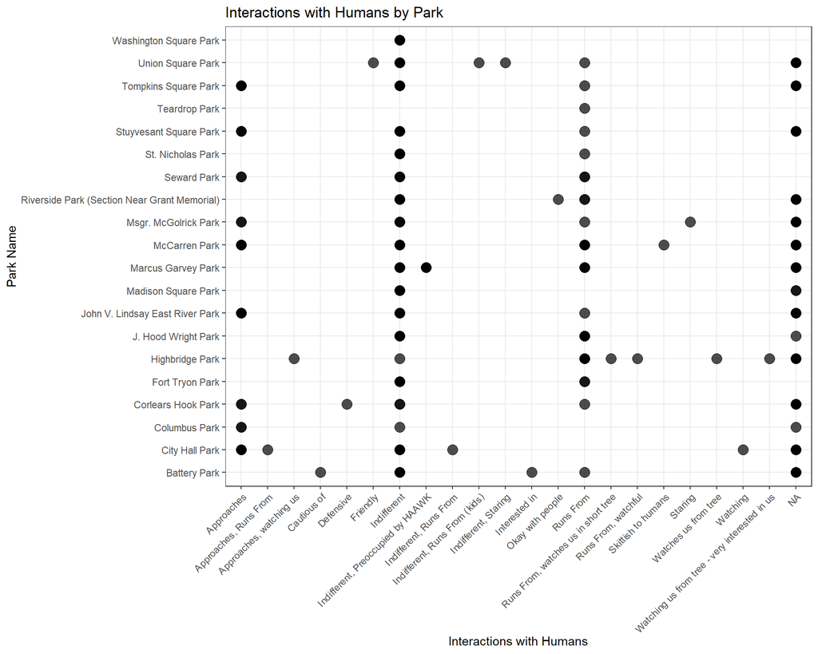

```r
# Create ggplot scatter plot
ggplot(squirrel_data, aes(x = `Interactions with Humans`, y = `Park Name`)) +
  geom_point(color = "black", size = 4, alpha = 0.7) +
  labs(
    title = "Interactions with Humans by Park",
    x = "Interactions with Humans",
    y = "Park Name"
  ) +
  theme_bw() +
  theme(axis.text.x = element_text(angle = 45, hjust = 1))
```

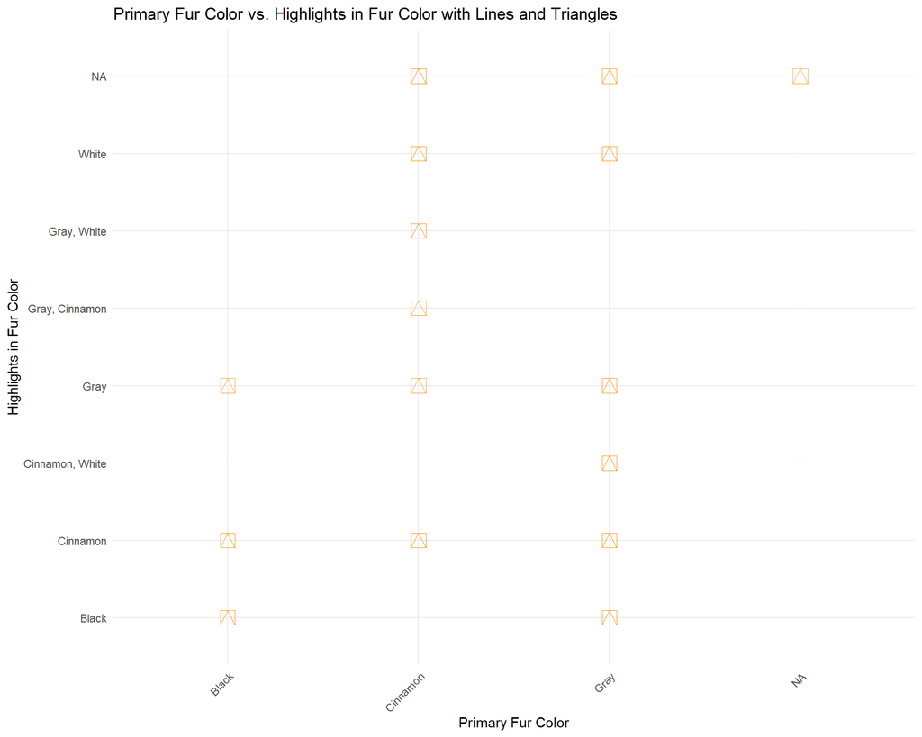

```r
ggplot(squirrel_data, aes(x = `Primary Fur Color`, y = `Highlights in Fur Color`)) +
  geom_point(shape = 14, color = "darkorange", size = 5, alpha = 0.8) +  # Use filled triangles (shape = 19)
  geom_segment(aes(xend = `Primary Fur Color`, yend = `Highlights in Fur Color`),
               color = "red", alpha = 0.5, size = 1) +
  labs(
    title = "Primary Fur Color vs. Highlights in Fur Color with Lines and Triangles",
    x = "Primary Fur Color",
    y = "Highlights in Fur Color"
  ) +
  theme_minimal() +
  theme(axis.text.x = element_text(angle = 45, hjust = 1))
```

Most notably, it’s valuable for creating heat density maps that can be beneficial for a wide range of data visualizations.

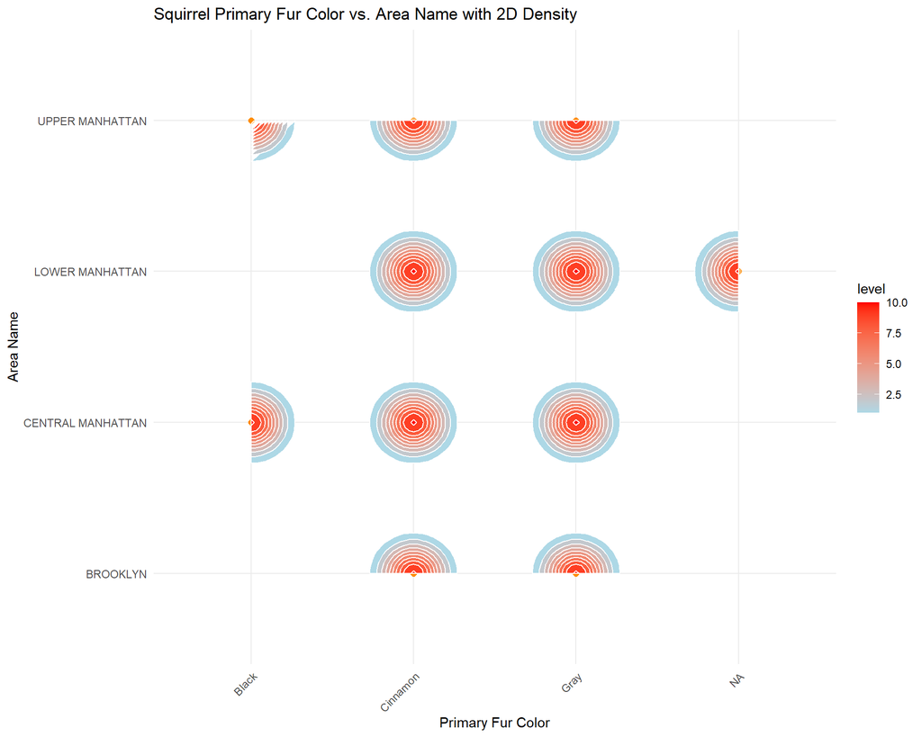

```r
ggplot(squirrel_data, aes(x = `Primary Fur Color`, y = `Area Name`)) +
  geom_point(color = "darkorange", size = 2, alpha = 0.6) +
  stat_density_2d(aes(fill = ..level..), geom = "polygon", color = "white", h = 0.5) +
  scale_fill_gradient(low = "lightblue", high = "red") +
  labs(
    title = "Squirrel Primary Fur Color vs. Area Name with 2D Density",
    x = "Primary Fur Color",
    y = "Area Name"
  ) +
  theme_minimal() +
  theme(axis.text.x = element_text(angle = 45, hjust = 1))
```

# Further Resources

Learn more about the Squirrel Census, ggplot2 scatterplots, and in-built ggplot2 themes using the following resources.

*Resource IV [https://www.youtube.com/watch?v=WF0gUJB0NMU](https://urldefense.com/v3/__https://www.youtube.com/watch?v=WF0gUJB0NMU__;!!IKRxdwAv5BmarQ!YCMMZzRZ_D7rzegK_emw1muRkXIffU3Y1Fj0H4Xq_bHVYKWw2qDkbb9IVkuPr79js2kYUMYN0DxoZUaHWRpm$)

# Works Cited

This code through references and cites the following sources:

- Statistical Tools for High-Throughput Data Analysis0 STHDA (N.D.). Source I. http://www.sthda.com/english/wiki/ggplot2-scatter-plots-quick-start-guide-r-software-and-data-visualization
- Jarad Niemi (2023). Source II. [https://www.youtube.com/watch?v=WF0gUJB0NMU](https://urldefense.com/v3/__https://www.youtube.com/watch?v=WF0gUJB0NMU__;!!IKRxdwAv5BmarQ!YCMMZzRZ_D7rzegK_emw1muRkXIffU3Y1Fj0H4Xq_bHVYKWw2qDkbb9IVkuPr79js2kYUMYN0DxoZUaHWRpm$))
- RCharts (N.D). Source III. [https://r-charts.com/ggplot2/themes/](https://urldefense.com/v3/__https://r-charts.com/ggplot2/themes/__;!!IKRxdwAv5BmarQ!YCMMZzRZ_D7rzegK_emw1muRkXIffU3Y1Fj0H4Xq_bHVYKWw2qDkbb9IVkuPr79js2kYUMYN0DxoZQFYX5gX$) and [https://r-charts.com/ggplot2/themes/](https://urldefense.com/v3/__https://r-charts.com/ggplot2/themes/__;!!IKRxdwAv5BmarQ!YCMMZzRZ_D7rzegK_emw1muRkXIffU3Y1Fj0H4Xq_bHVYKWw2qDkbb9IVkuPr79js2kYUMYN0DxoZQFYX5gX$) for information on element text modifications.